# Thesis Related Analyses for Pre-tumor Stage dataset

Tanvi Nagpal

2024-07-23

# RNA-seq analysis for CLL dataset 1 (Pre-tumor Stage Dataset):

# Packages

```r
library(edgeR)
library(limma)
library(vsn)
library(org.Mm.eg.db)
library(ggplot2)
library(knitr)
library(kableExtra)
library(dplyr)
library(VennDiagram)
library(gridExtra)
library(topGO)
library(ReactomePA)
library(sva)
library(DGE.Tools2)
library(UpSetR)
```

# edgeR

## Data preprocessing

First, we create a DGElist.

```r
# Load data
rawcounts <- read.table("VS01_Mouse_DGE_Matrix.txt", header = TRUE, sep = "\t")

# Set rownames to first column (column has no title and contains ENSEMBL ids)
rownames(rawcounts) <- rawcounts[, 1]
rawcounts <- rawcounts[,-1]

# Explore the first six observations of the raw counts
head(rawcounts)
```

```
##               AATACA ATTCTA TACTAT TTGAAA CCAACC CCGTCG GAGCGG GGGCAG AATCTT
## 0610005C13Rik      0      0      0      0      0      1      0      2      0
## 0610006L08Rik      0      0      0      0      0      0      0      0      0
## 0610009B22Rik     31     17     35     16     28     18     24     21     12
## 0610009E02Rik      0      0      0      0      0      0      2      1      0
## 0610009L18Rik      3      8      9      5      3      1      3      3      5
## 0610010F05Rik      0      0      1      0      1      1      0      0      0
##               ATTTCA TAGTAA TTTACA GTACCG CCTGGC GCACGG GGGGAC AATTCT CAAATA
## 0610005C13Rik      1      2      0      0      0      0      0      0      0
## 0610006L08Rik      0      0      0      0      0      0      0      0      0
## 0610009B22Rik     27     25     25     17     21     19     17     30     25
## 0610009E02Rik      0      0      1      0      1      0      0      0      0
## 0610009L18Rik      7      4      2      3      3      2      8      2      6
## 0610010F05Rik      1      4      0      2      1      1      2      3      1
##               TATAGA TTTCTT ACCGGC CGAGGC GCCAGG GGGTCG ACAATA CATTAT TATGAA
## 0610005C13Rik      0      0      0      0      0      0      0      0      0
## 0610006L08Rik      0      0      0      0      0      0      0      0      1
## 0610009B22Rik     40     26     28     17     20     11     13     11     18
## 0610009E02Rik      0      2      1      1      1      1      0      0      0
## 0610009L18Rik      6     11      6      5      3      2      3      1      4
## 0610010F05Rik      1      3      2      4      1      0      0      1      1
##               TTTTGA ACGGGG CGCCCT GCCCTC GGTGGC ACTTAT CTATAT TATTGT
## 0610005C13Rik      0      1      0      0      0      0      0      0
## 0610006L08Rik      0      0      0      0      0      0      0      0
## 0610009B22Rik     16     25     25     23     16     30     11     13
## 0610009E02Rik      1      0      0      1      0      0      1      0
## 0610009L18Rik      5      1      5      2      0      4      2      1
## 0610010F05Rik      0      1      1      2      0      1      2      2
```

```r
# Explore the structure of the raw counts
str(rawcounts)
```

```
## 'data.frame':    25126 obs. of  35 variables:
##  $ AATACA: int  0 0 31 0 3 0 0 63 0 35 ...
##  $ ATTCTA: int  0 0 17 0 8 0 0 48 0 24 ...
##  $ TACTAT: int  0 0 35 0 9 1 1 68 0 28 ...
##  $ TTGAAA: int  0 0 16 0 5 0 0 55 0 29 ...
##  $ CCAACC: int  0 0 28 0 3 1 2 48 0 26 ...
##  $ CCGTCG: int  1 0 18 0 1 1 0 53 0 21 ...
##  $ GAGCGG: int  0 0 24 2 3 0 0 48 0 30 ...
##  $ GGGCAG: int  2 0 21 1 3 0 4 45 0 40 ...
##  $ AATCTT: int  0 0 12 0 5 0 1 77 0 19 ...
##  $ ATTTCA: int  1 0 27 0 7 1 0 34 0 29 ...
##  $ TAGTAA: int  2 0 25 0 4 4 4 66 0 51 ...
##  $ TTTACA: int  0 0 25 1 2 0 1 80 0 28 ...
##  $ GTACCG: int  0 0 17 0 3 2 0 51 0 29 ...
##  $ CCTGGC: int  0 0 21 1 3 1 4 58 1 24 ...
```

[output cut: 21 more lines]

```r
# Load meta data
metadata <- read.csv("metadata_muc002.csv", row.names = 1, sep = ",")

#remove age 9 months and Old age samples:
metadata <- metadata[metadata$Age_months == 3, ]

# Use the match() function to reorder the columns of the raw counts
reorder_idx <- match(rownames(metadata), colnames(rawcounts[1:28,]))
# Reorder the columns of the count data
reordered_rawcounts <- rawcounts[ , reorder_idx]

#Get back the genes column#
reordered_rawcounts2 <- tibble::rownames_to_column(reordered_rawcounts, "genes")
dge <-DGEList(counts=reordered_rawcounts2[,2:29], genes=reordered_rawcounts2[,1], group = metadata$Group)
```

Create initial model design

```r
design_edgeR <- model.matrix(~metadata$Group)
```

The design setup will later be used for the dispersion estimates and for the differential gene expression analysis.

## Normalisation

### Filter out lowly expressed genes

Genes are dropped if they are not expressed in all the samples for any of the conditions. This allows to only keep genes that are expressed at a biologically meaningful level, to better estimate the mean-variance relationship in the data and reduces the number of statistical tests that need to be carried out when looking at differential expression. By default, the function `filterByExpr()` keeps genes with about 10 read counts or more in a minimum number of samples, where the number of samples is chosen according to the minimum group sample size. The data is filtered with counts-per-million (CPM; `cpm()`) rather than with the counts directly because the latter does not account for differences in library sizes between samples.

```r
cpm <- cpm(dge)
keep.exprs <- filterByExpr(dge,group=dge$group)
dge <- dge[keep.exprs,keep.lib.sizes=FALSE]
```

8010 genes are kept for the rest of the analysis after this step.

### Correction for the library sizes

Normalisation by the method of trimmed mean of M-values (TMM) is performed (`normLibSizes()`). The normalisation factors calculated here are used as a scaling factor for the library sizes. A normalisation factor below one indicates that a small number of high count genes are monopolizing the sequencing, causing the counts for other genes to be lower than would be usual given the library size. In this case, the library size is scaled down. Conversely, a normalisation factor above one scales up the library size.

```r
dge <- normLibSizes(dge,method="TMM")
kable(dge$samples,caption="Table 1: library sizes and normalisation factors for each sample.") %>%
  kable_styling(bootstrap_options="striped",full_width=F)
```

Table 1: library sizes and normalisation factors for each sample.

|  | group | lib.size | norm.factors |
| --- | --- | --- | --- |
| GGGCAG | Control_PC | 504452 | 1.0259670 |
| GCCAGG | Control_PC | 526321 | 1.0289793 |
| TTGAAA | Control_PC | 451849 | 1.0064023 |
| ATTCTA | Control_Spl | 586272 | 0.8879590 |
| CCGTCG | Control_Spl | 439036 | 0.9260471 |
| AATACA | Mild_BCL_PC | 582295 | 1.0088531 |
| TAGTAA | Mild_BCL_PC | 645867 | 1.0240922 |
| TATGAA | Mild_BCL_PC | 415346 | 0.9916166 |
| ATTTCA | Mild_BCL_SPL | 458617 | 0.9913690 |
| GTACCG | Mild_BCL_SPL | 451556 | 1.0105520 |
| ACAATA | Strong_BCL_PC | 365321 | 0.9450020 |
| CATTAT | Strong_BCL_PC | 356282 | 0.9719859 |
| GGTGGC | Strong_BCL_PC | 429547 | 1.0129811 |
| ACCGGC | Strong_BCL_Spl | 560542 | 1.0393575 |
| CGAGGC | Strong_BCL_Spl | 348927 | 1.0606400 |
| TTTTGA | Strong_BCL_Spl | 321151 | 1.0246165 |
| CCAACC | CLL_PC | 460511 | 0.9840477 |
| AATCTT | CLL_PC | 378510 | 0.9651460 |
| GCACGG | CLL_Spl | 186492 | 0.9860775 |
| TTTCTT | CLL_Spl | 817135 | 1.0125819 |
| GGGTCG | CLL_PC | 455504 | 1.0165908 |
| GGGGAC | CLL_Spl | 450665 | 1.0140091 |
| TTTACA | Mild_CLL_PC | 580849 | 1.0140352 |
| ACTTAT | Mild_CLL_PC | 576792 | 1.0210653 |
| CCTGGC | Mild_CLL_PC | 459355 | 1.0012007 |
| TACTAT | Mild_CLL_Spl | 693055 | 0.9728566 |
| GAGCGG | Mild_CLL_Spl | 361028 | 1.0437545 |
| ACGGGG | Mild_CLL_Spl | 399175 | 1.0312312 |

### Dispersion estimation

edgeR uses the negative binomial distribution to model the read counts for each gene in each sample. The `estimateDisp()` function estimates a dispersion for each individual gene, a common dispersion (global dispersion estimate averaged over all genes) and a trended dispersion (dispersion of a gene predicted from its abundance).

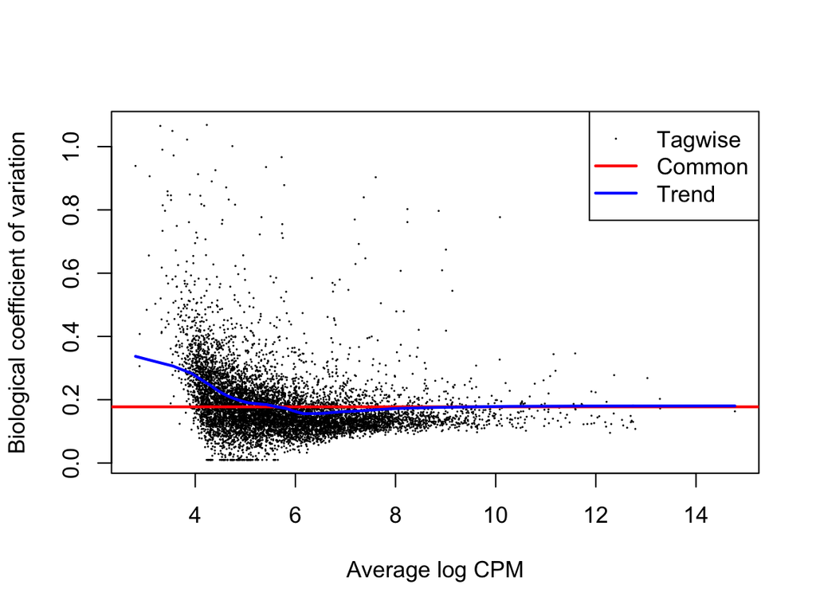

Figure 1: Dispersion estimation (edgeR). Biological coefficient of variation (square root of dispersions) against the average abundance of each gene (log2-CPM). Square-root estimates of the common, trended and tagwise negative binomial dispersions are represented.

```r
dge <- estimateDisp(dge,design_edgeR)
plotBCV(dge)
```

For RNA-seq studies, the negative binomial dispersions tend to be higher for genes with very low counts. The dispersion trend tends to decrease smoothly with abundance and to asymptotic to a constant value for genes with larger counts. But in this case, the decrease is not quite smooth, indicating unexpected variation in the dataset.

## Data visualisation

A multi-dimensional scaling plot is used to cluster the samples in two dimensions. The distance between each sample represents the leading log fold change for the genes that best distinguish those samples. The leading fold change is defined as the mean-root-square of the largest 500 log2-fold changes between a pair of samples. `ggplotMDS()` function is used here to visualise both genotype and organ related clusters.

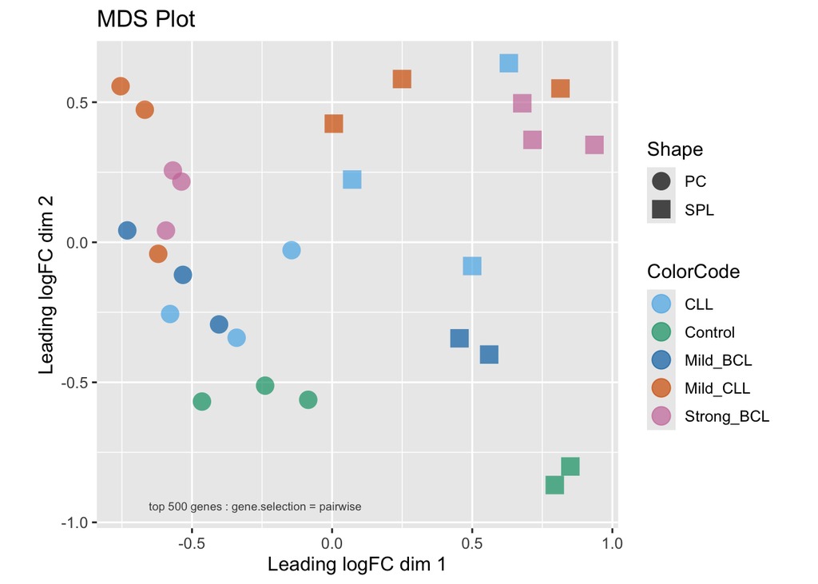

Figure 2: Multidimensional scaling plot of distances between gene expression profiles. Distances on the plot approximate the typical log2 fold changes between the samples.

There is some separation on the X axis based on organ type. However, separation due to Genotype is not evident in the clusters on Y axis. This indicates presence of unknown batch effects which we will correct for using Surrogate Variables through SVA-seq analysis.

### SVA-seq analysis:

```r
#run sva seq on the log cpm values and find surrogate variables:
dat2  <- cpm(dge$counts, log=TRUE)
idx2  <- rowMeans(dat2) > 1
dat2  <- dat2[idx2, ]
dge$samples$group <- relevel(dge$samples$group, ref="Control_PC")
Group <- dge$samples$group
mod_e  <- model.matrix(~Group)
svseq_e <- svaseq(dat2, mod_e, mod_e[,1])
```

```
## Number of significant surrogate variables is:  6
## Iteration (out of 5 ):1  2  3  4  5
```

```r
svseq_e$sv
```

```
##                [,1]        [,2]        [,3]          [,4]        [,5]
##  [1,]  0.0476541750 -0.05917791  0.24679975 -0.0840247588  0.02215297
##  [2,]  0.0079132230 -0.09709756  0.25392109 -0.2166504331  0.04178887
##  [3,]  0.1025733333 -0.13742288  0.32238910 -0.0922765862 -0.08300517
##  [4,] -0.1487847826  0.07086323  0.11356473 -0.0159427021  0.03629950
##  [5,] -0.1344960562  0.04787855  0.09431977 -0.1509351246  0.02091485
##  [6,]  0.1215447210 -0.17414463  0.09371042  0.0751574647 -0.16862104
##  [7,]  0.1539443215 -0.15149517 -0.05150607  0.0892865733 -0.14930366
##  [8,]  0.1624551392 -0.05654110  0.03233205 -0.1976019735 -0.02367397
##  [9,] -0.1140565909 -0.06365991  0.04706358 -0.0784573400 -0.18921500
## [10,] -0.1318883229 -0.08609825  0.11245520 -0.0735373148 -0.16732851
## [11,]  0.3510965802  0.05464042 -0.29543317 -0.2619488025  0.20752054
## [12,]  0.2833980706 -0.02938139 -0.41341511 -0.1471857055  0.06437992
## [13,]  0.1549536554 -0.08609542 -0.22704814 -0.0682387900 -0.02633866
## [14,] -0.2389135199 -0.03194669 -0.18081362  0.0460749051  0.04279897
```

[output cut: 43 more lines]

```r
#remove batch effects for visualising:
logCPM <- cpm(dge,log=TRUE)
batchy <- svseq_e$sv
logCPM <- removeBatchEffect(logCPM,covariates=batchy, design = design_edgeR)
```

Now that we have identified 6 Surrogate Variables for this dataset, we will see whether they indeed remove the batch effects seen previously by re-doing estimating dispersion and plotting a new MDS plot.

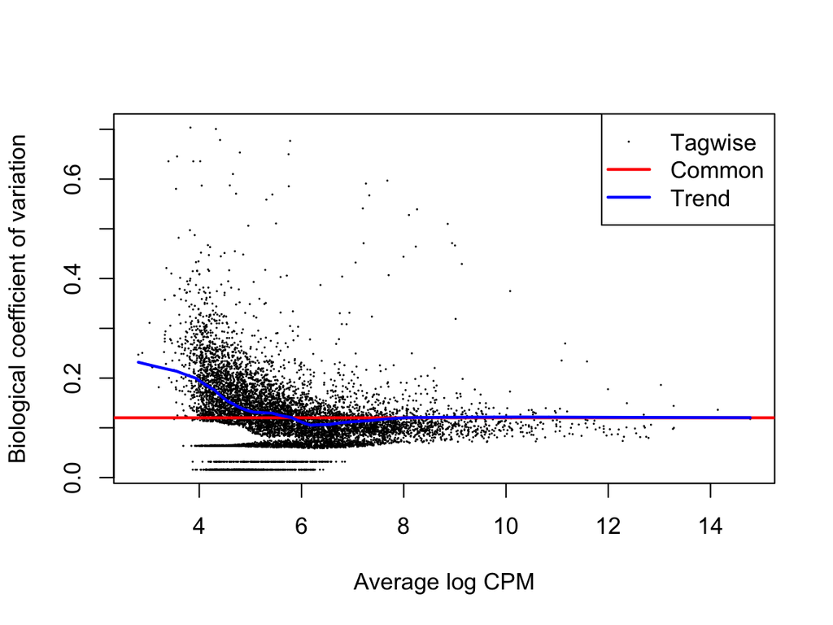

Figure 3: New BCV plot after batch correction.

```r
metadata.sv <- cbind(metadata, svseq_e$sv)

colnames(metadata.sv)[6:11] <- paste0("sv", 1:6)

design_edgeR2 <- model.matrix(~ 0 + metadata.sv$sv1 + metadata.sv$sv2 + metadata.sv$sv3 + metadata.sv$sv4 + metadata.sv$sv5 + metadata.sv$sv6 + metadata.sv$Group)

colnames(design_edgeR2) <- c('SV1','SV2','SV3', 'SV4', 'SV5', 'SV6', "Control_PC", "Control_Spl", "mild_BCL_PC", "mild_BCL_Spl", "strong_BCL_PC", "strong_BCL_Spl", "CLL_PC", "CLL_Spl", "mild_CLL_PC", "mild_CLL_Spl")

dge_edgeR.sv <- estimateDisp(dge,design_edgeR2)
plotBCV(dge_edgeR.sv)
```

There is a big change in dispersion observed, the BCV is now much lower for lower cpm, showing decreased variation after inclusion of surrogate variables. Next, we create a new MDS plot.

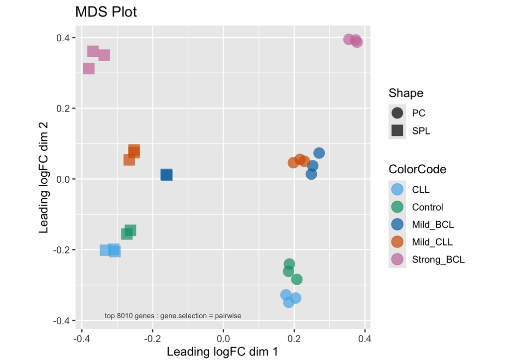

Figure 4: Multidimensional scaling plot of distances between gene expression profiles. Distances on the plot approximate the typical log2 fold changes between the samples.

A clear separation of clusters is observed after batch effect removal in the MDS plot. The first dimension separates based on the organ type and the second dimension separates based on type (and strength) of lymphoma. Therefore, SVA-seq works really well in removal of unknown and unintended batch effects. Now, we can move on to the differential gene expression analysis.

## Differential gene expression

edgeR uses the dispersion estimates to test whether the observed gene counts fit a negative binomial model (`glmQLFit()` and `glmQLFTest()`). Then, `topTags()` extracts the most DEGs ranked by their log FC.

```r
#fit the negative binomial model:
fit1 <- glmQLFit(dge_edgeR.sv,design_edgeR2)

#setup the 8 pairwise comparisons as contrasts:
my.contrasts <- makeContrasts(CllPvsCP=CLL_PC-Control_PC, CllSvsCS=CLL_Spl-Control_Spl, sBPvsmBP=strong_BCL_PC-mild_BCL_PC, sBSvsmBS=strong_BCL_Spl-mild_BCL_Spl, mCPvsCllP = mild_CLL_PC-CLL_PC, mCSvsCllS = mild_CLL_Spl-CLL_Spl, mCPvsmBP = mild_CLL_PC-mild_BCL_PC, mCSvsmBS = mild_CLL_Spl-mild_BCL_Spl, levels=design_edgeR2)

#test each contrast:
qlf1 <- glmQLFTest(fit1,  contrast=my.contrasts[,"CllPvsCP"])
qlf2 <- glmQLFTest(fit1,  contrast=my.contrasts[,"CllSvsCS"])
qlf3 <- glmQLFTest(fit1,  contrast=my.contrasts[,"sBPvsmBP"])
qlf4 <- glmQLFTest(fit1,  contrast=my.contrasts[,"sBSvsmBS"])
qlf5 <- glmQLFTest(fit1,  contrast=my.contrasts[,"mCPvsCllP"])
qlf6 <- glmQLFTest(fit1,  contrast=my.contrasts[,"mCSvsCllS"])
qlf7 <- glmQLFTest(fit1,  contrast=my.contrasts[,"mCPvsmBP"])
qlf8 <- glmQLFTest(fit1,  contrast=my.contrasts[,"mCSvsmBS"])

##checking results for each comparison:
results1_edgeR<- topTags(qlf1,n=Inf,sort.by="logFC",adjust.method="BH")
summary(decideTests(qlf1,p.value=0.05))
```

```
##        -1*Control_PC 1*CLL_PC
## Down                        1
## NotSig                   8000
## Up                          9
```

```r
topTags(qlf1)
```

```
## Coefficient:  -1*Control_PC 1*CLL_PC
##           genes     logFC   logCPM        F       PValue        FDR
## 17359     Mndal  1.540387 7.455213 29.03984 7.527725e-06 0.03255373
## 3248        Cfp  1.479102 9.327083 28.74795 8.128271e-06 0.03255373
## 5330     Fcer1g  2.593248 5.762085 26.48400 1.384979e-05 0.03315554
## 15742  Igkv4-91  3.141342 7.376501 26.13723 1.655707e-05 0.03315554
## 15811     Il12a  3.393552 4.909362 24.46624 2.646562e-05 0.04036227
## 2333      Blvrb  1.449716 7.078533 23.22782 3.785911e-05 0.04036227
## 19085      Phkb  2.780313 5.052013 22.82114 4.180237e-05 0.04036227
## 15658 Igkv1-135  6.936758 5.313230 22.36404 4.188063e-05 0.04036227
## 15172  Hepacam2 -1.676655 7.207927 22.61726 4.535087e-05 0.04036227
## 15726  Igkv4-68 11.715490 3.297569 26.78373 6.024795e-05 0.04825861
```

```r
results2_edgeR<- topTags(qlf2,n=Inf,sort.by="logFC",adjust.method="BH")
summary(decideTests(qlf2,p.value=0.05))
```

```
##        -1*Control_Spl 1*CLL_Spl
## Down                          1
## NotSig                     8004
## Up                            5
```

```r
topTags(qlf2)
```

```
## Coefficient:  -1*Control_Spl 1*CLL_Spl
##           genes     logFC   logCPM        F       PValue          FDR
## 15665 Igkv10-96 -5.526375 6.937684 53.89288 3.407951e-08 0.0001403134
## 17183      Mgmt  3.257839 6.448921 53.62211 3.503456e-08 0.0001403134
## 3248        Cfp  1.462587 9.327083 38.86000 6.946171e-07 0.0018546277
## 15118       Hck  1.066530 7.679090 28.91821 7.771805e-06 0.0155630394
## 17359     Mndal  1.248741 7.455213 25.71600 1.854973e-05 0.0297166754
## 16738       Ltb  1.328477 9.503243 24.12360 2.915812e-05 0.0389260942
## 21914      Slpi -4.106827 5.591029 21.96466 4.755950e-05 0.0544216510
## 21623    Slamf6  1.147688 7.421769 21.05641 7.268429e-05 0.0727751462
## 2333      Blvrb  1.109311 7.078533 19.37130 1.231749e-04 0.1096256448
## 17004       Mcc  8.100154 3.431836 18.59641 1.549944e-04 0.1191092597
```

```r
results3_edgeR<- topTags(qlf3,n=Inf,sort.by="logFC",adjust.method="BH")
summary(decideTests(qlf3,p.value=0.05))
```

```
##        -1*mild_BCL_PC 1*strong_BCL_PC
## Down                                0
## NotSig                           8009
## Up                                  1
```

```r
topTags(qlf3)
```

```
## Coefficient:  -1*mild_BCL_PC 1*strong_BCL_PC
##            genes      logFC   logCPM        F       PValue        FDR
## 17359      Mndal  1.3332451 7.455213 30.00199 5.856217e-06 0.04690830
## 5628     Gadd45g -3.6547422 4.140505 25.81074 1.503344e-05 0.06020894
## 5579       Fxyd6  2.4370438 5.020355 19.22628 1.215810e-04 0.31352441
## 22930    Themis2  1.3728065 6.782604 18.50122 1.630043e-04 0.31352441
## 21160       Saa3  7.5019241 3.883646 17.92633 1.957081e-04 0.31352441
## 16059      Jade2 -2.1619402 4.702283 16.35546 3.286648e-04 0.40035205
## 2975        Cd55  0.9194758 7.843297 16.21260 3.498707e-04 0.40035205
## 975   AC168977.1 -3.5524743 6.370291 15.54441 4.314732e-04 0.41010748
## 15172   Hepacam2 -1.1149885 7.207927 15.12800 5.101824e-04 0.41010748
## 3248         Cfp  0.9260349 9.327083 15.11742 5.119944e-04 0.41010748
```

```r
results4_edgeR<- topTags(qlf4,n=Inf,sort.by="logFC",adjust.method="BH")
summary(decideTests(qlf4,p.value=0.05))
```

```
##        -1*mild_BCL_Spl 1*strong_BCL_Spl
## Down                                 22
## NotSig                             7985
## Up                                    3
```

```r
topTags(qlf4)
```

```
## Coefficient:  -1*mild_BCL_Spl 1*strong_BCL_Spl
##          genes     logFC    logCPM         F       PValue          FDR
## 15745 Igkv5-39 -5.780602  8.158032 166.63495 7.805153e-14 6.251928e-10
## 21819   Slc3a2 -1.938146  8.181920  83.83905 3.098602e-10 1.240990e-06
## 15565     Ighm -1.242586 14.143402  42.61562 3.061610e-07 8.174500e-04
## 15553     Igha -5.351187  7.995069  41.02228 4.313976e-07 8.638737e-04
## 15558   Ighg2b -2.895701  5.187480  33.62760 2.382968e-06 3.817515e-03
## 15764 Igkv8-24 -3.710443  4.884219  31.14574 3.060845e-06 4.086228e-03
## 21914     Slpi -5.245329  5.591029  30.29476 4.338934e-06 4.964980e-03
## 3715    Creld2 -1.421550  8.185285  30.50713 5.140645e-06 5.147071e-03
## 23822   Txndc5 -1.000451  8.505507  27.03462 1.288173e-05 1.146474e-02
## 3690       Cr2  2.934427  5.081491  25.67364 1.735431e-05 1.390080e-02
```

```r
results5_edgeR<- topTags(qlf5,n=Inf,sort.by="logFC",adjust.method="BH")
summary(decideTests(qlf5,p.value=0.05))
```

```
##        -1*CLL_PC 1*mild_CLL_PC
## Down                         1
## NotSig                    8009
## Up                           0
```

```r
topTags(qlf5)
```

```
## Coefficient:  -1*CLL_PC 1*mild_CLL_PC
##            genes     logFC    logCPM        F       PValue          FDR
## 16404       Krt8 -3.831621  7.547222 49.24430 8.054785e-08 0.0006451883
## 20613       Rpia -5.458920  4.854852 24.18469 2.572516e-05 0.0651731956
## 1100        Abi3 -2.125039  6.662177 23.58994 3.406210e-05 0.0651731956
## 5349       Fcrla -1.256562  9.145550 22.90046 4.168326e-05 0.0651731956
## 15849      Il4i1  2.405766  7.030198 22.56879 4.605368e-05 0.0651731956
## 3441        Cln3 -3.069082  5.316327 22.38538 4.881887e-05 0.0651731956
## 16094       Jund -1.668297  6.436397 21.49196 6.364746e-05 0.0728308753
## 1662     Apobec1  1.392577  6.696599 20.46722 8.723993e-05 0.0786663620
## 16756       Ly6a  1.037596 10.973887 20.42370 8.838917e-05 0.0786663620
## 15685 Igkv14-126 -4.451087  8.235766 19.64282 1.130309e-04 0.0905377306
```

```r
results6_edgeR<- topTags(qlf6,n=Inf,sort.by="logFC",adjust.method="BH")
summary(decideTests(qlf6,p.value=0.05))
```

```
##        -1*CLL_Spl 1*mild_CLL_Spl
## Down                           9
## NotSig                      7977
## Up                            24
```

```r
topTags(qlf6)
```

```
## Coefficient:  -1*CLL_Spl 1*mild_CLL_Spl
##           genes     logFC    logCPM        F       PValue          FDR
## 15673 Igkv12-46  6.876517  7.215049 65.11748 4.147549e-09 2.487476e-05
## 16779     Lynx1  2.853154  6.188805 63.61460 6.210925e-09 2.487476e-05
## 15269     Hmgn1 -1.576485  7.759946 35.52294 1.496837e-06 3.414703e-03
## 21591     Sirt2  1.896202  7.448523 34.58424 1.871716e-06 3.414703e-03
## 2951    Cd300ld  4.561037  4.645177 33.09171 2.131525e-06 3.414703e-03
## 3262    Chchd10  2.328120  5.936150 32.73481 2.881018e-06 3.846158e-03
## 4072     Dcaf12 -1.705732  6.894900 28.52279 8.631172e-06 8.761725e-03
## 16760      Ly6d  1.151815 11.055454 28.06534 9.747756e-06 8.761725e-03
## 22596    Syngr2  1.198638  7.759686 28.02888 9.844635e-06 8.761725e-03
## 16523  Lgals3bp  2.008152  6.175528 26.63894 1.437124e-05 1.151137e-02
```

```r
results7_edgeR<- topTags(qlf7,n=Inf,sort.by="logFC",adjust.method="BH")
summary(decideTests(qlf7,p.value=0.05))
```

```
##        -1*mild_BCL_PC 1*mild_CLL_PC
## Down                              0
## NotSig                         8009
## Up                                1
```

```r
topTags(qlf7)
```

```
## Coefficient:  -1*mild_BCL_PC 1*mild_CLL_PC
##          genes     logFC   logCPM        F       PValue       FDR
## 17359    Mndal  2.114116 7.455213 30.21657 5.540475e-06 0.0443792
## 16486     Lcp1  1.189318 9.403015 22.35724 4.899152e-05 0.1870752
## 15172 Hepacam2 -2.290764 7.207927 21.17656 7.006560e-05 0.1870752
## 19085     Phkb  4.423749 5.052013 18.29492 1.716376e-04 0.3007832
## 23756      Ttn  4.712292 4.365892 17.34933 1.877548e-04 0.3007832
## 17544   Ms4a4c  3.531827 5.387102 16.84460 2.819776e-04 0.3634865
## 4210      Dffb -3.992792 4.426991 16.31121 3.417111e-04 0.3634865
## 14032   Gm8231 -3.310043 4.787395 15.89192 3.951927e-04 0.3634865
## 17547   Ms4a6c  2.099991 8.056726 15.37278 4.680823e-04 0.3634865
## 4917     Erbin  3.172494 4.853695 15.22519 4.939564e-04 0.3634865
```

```r
results8_edgeR<- topTags(qlf8,n=Inf,sort.by="logFC",adjust.method="BH")
summary(decideTests(qlf8,p.value=0.05))
```

```
##        -1*mild_BCL_Spl 1*mild_CLL_Spl
## Down                               24
## NotSig                           7970
## Up                                 16
```

```r
topTags(qlf8)
```

```
## Coefficient:  -1*mild_BCL_Spl 1*mild_CLL_Spl
##               genes     logFC    logCPM        F       PValue          FDR
## 15745      Igkv5-39 -7.326122  8.158032 90.64780 1.313368e-10 1.052008e-06
## 15645          Igkc -1.672342 14.776907 59.58701 1.212730e-08 4.856983e-05
## 15565          Ighm -1.799603 14.143402 48.30996 9.574719e-08 2.556450e-04
## 16760          Ly6d  1.591165 11.055454 35.26691 1.590024e-06 3.184022e-03
## 16072        Jchain -3.330208 11.157767 31.67538 3.820523e-06 6.120477e-03
## 21140       S100a10 -1.617579 10.025012 30.93324 4.609635e-06 6.153863e-03
## 17183          Mgmt  2.987430  6.448921 30.28234 5.455271e-06 6.242389e-03
## 21819        Slc3a2 -1.583466  8.181920 29.03429 7.537279e-06 7.490518e-03
## 382   3300005D01Rik  4.859806  4.471143 28.57518 8.416312e-06 7.490518e-03
## 21591         Sirt2  2.234042  7.448523 27.82763 1.039336e-05 8.325083e-03
```

```r
# retrieve gene symbols for each contrast and adjust p values for number of pairwise comparisons:
results1_df <- as.data.frame(results1_edgeR)
results1_df <- results1_df %>% dplyr::rename("SYMBOL"="genes")
results1_df[,6] <- results1_df[,6] * 8
DEGs1 <- results1_df %>% filter(FDR<=0.05)

results2_df <- as.data.frame(results2_edgeR)
results2_df <- results2_df %>% dplyr::rename("SYMBOL"="genes")
results2_df[,6] <- results2_df[,6] * 8
DEGs2 <- results2_df %>% filter(FDR<=0.05)

results3_df <- as.data.frame(results3_edgeR)
results3_df <- results3_df %>% dplyr::rename("SYMBOL"="genes")
results3_df[,6] <- results3_df[,6] * 8
DEGs3 <- results3_df %>% filter(FDR<=0.05)

results4_df <- as.data.frame(results4_edgeR)
results4_df <- results4_df %>% dplyr::rename("SYMBOL"="genes")
results4_df[,6] <- results4_df[,6] * 8
DEGs4 <- results4_df %>% filter(FDR<=0.05)

results5_df <- as.data.frame(results5_edgeR)
results5_df <- results5_df %>% dplyr::rename("SYMBOL"="genes")
results5_df[,6] <- results5_df[,6] * 8
DEGs5 <- results5_df %>% filter(FDR<=0.05)

results6_df <- as.data.frame(results6_edgeR)
results6_df <- results6_df %>% dplyr::rename("SYMBOL"="genes")
results6_df[,6] <- results6_df[,6] * 8
DEGs6 <- results6_df %>% filter(FDR<=0.05)

results7_df <- as.data.frame(results7_edgeR)
results7_df <- results7_df %>% dplyr::rename("SYMBOL"="genes")
results7_df[,6] <- results7_df[,6] * 8
DEGs7 <- results7_df %>% filter(FDR<=0.05)

results8_df <- as.data.frame(results8_edgeR)
results8_df <- results8_df %>% dplyr::rename("SYMBOL"="genes")
results8_df[,6] <- results8_df[,6] * 8
DEGs8 <- results8_df %>% filter(FDR<=0.05)

significant_DEGs_spleen <- data.frame(
  Contrasts_Spleen = c("CLL vs Control", "Strong BCL vs Mild BCL", "Mild CLL vs CLL", "Mild CLL vs Mild BCL"),
  Significant_DEGs = c(3,8,6,7)
)
significant_DEGs_spleen
```

```
##         Contrasts_Spleen Significant_DEGs
## 1         CLL vs Control                3
## 2 Strong BCL vs Mild BCL                8
## 3        Mild CLL vs CLL                6
## 4   Mild CLL vs Mild BCL                7
```

```r
significant_DEGs_pc <- data.frame(
  Contrasts_PC = c("CLL vs Control", "Strong BCL vs Mild BCL", "Mild CLL vs CLL", "Mild CLL vs Mild BCL"),
  Significant_DEGs = c(0,0,1,0)
)
significant_DEGs_pc
```

```
##             Contrasts_PC Significant_DEGs
## 1         CLL vs Control                0
## 2 Strong BCL vs Mild BCL                0
## 3        Mild CLL vs CLL                1
## 4   Mild CLL vs Mild BCL                0
```

For this dataset, there was only 1 significant DEG (p < 0.05) for Peritoneal cavity comparison 5 (Mild CLL vs CLL) which is Krt8 and a total of 24 significant DEGs for Spleen among the 4 comparisons.

## GO analysis

```r
# build df with all assessed genes
GO1 <- results1_df
GO2 <- results2_df
GO3 <- results3_df
GO4 <- results4_df
GO5 <- results5_df
GO6 <- results6_df
GO7 <- results7_df
GO8 <- results8_df

# filter out missing adjusted pvalues
GO1 <- filter(GO1,FDR!="NA")
GO2 <- filter(GO2,FDR!="NA")
GO3 <- filter(GO3,FDR!="NA")
GO4 <- filter(GO4,FDR!="NA")
GO5 <- filter(GO5,FDR!="NA")
GO6 <- filter(GO6,FDR!="NA")
GO7 <- filter(GO7,FDR!="NA")
GO8 <- filter(GO8,FDR!="NA")

# retrieve adjusted pvalues
allGenes1 <- GO1[,6]
allGenes2 <- GO2[,6]
allGenes3 <- GO3[,6]
allGenes4 <- GO4[,6]
allGenes5 <- GO5[,6]
allGenes6 <- GO6[,6]
allGenes7 <- GO7[,6]
allGenes8 <- GO8[,6]

# retrieve symbols
names(allGenes1) <- GO1[,1]
names(allGenes2) <- GO2[,1]
names(allGenes3) <- GO3[,1]
names(allGenes4) <- GO4[,1]
names(allGenes5) <- GO5[,1]
names(allGenes6) <- GO6[,1]
names(allGenes7) <- GO7[,1]
names(allGenes8) <- GO8[,1]


# filter for significant DEGs (adjusted pvalue <=0.05)
top_diff_genes <- function(x){return(x<=0.05)}

# GO analysis
GOdata1 <- new("topGOdata",ontology="BP",allGenes=allGenes1,
                     geneSel=top_diff_genes,ID="SYMBOL",
                     mapping="org.Mm.eg.db",annot=annFUN.org)
fisher1 <- runTest(GOdata1,algorithm="elim",statistic="fisher")
allRes1 <- GenTable(GOdata1,classic=fisher1,
                          orderBy="fisher",ranksOf="classic",topNodes=500)

GOdata2 <- new("topGOdata",ontology="BP",allGenes=allGenes2,
                     geneSel=top_diff_genes,ID="SYMBOL",
                     mapping="org.Mm.eg.db",annot=annFUN.org)
fisher2 <- runTest(GOdata2,algorithm="elim",statistic="fisher")
allRes2 <- GenTable(GOdata2,classic=fisher2,
                          orderBy="fisher",ranksOf="classic",topNodes=500)

GOdata3 <- new("topGOdata",ontology="BP",allGenes=allGenes3,
                     geneSel=top_diff_genes,ID="SYMBOL",
                     mapping="org.Mm.eg.db",annot=annFUN.org)
fisher3 <- runTest(GOdata3,algorithm="elim",statistic="fisher")
allRes3 <- GenTable(GOdata3,classic=fisher3,
                          orderBy="fisher",ranksOf="classic",topNodes=500)

GOdata4 <- new("topGOdata",ontology="BP",allGenes=allGenes4,
                     geneSel=top_diff_genes,ID="SYMBOL",
                     mapping="org.Mm.eg.db",annot=annFUN.org)
fisher4 <- runTest(GOdata4,algorithm="elim",statistic="fisher")
allRes4 <- GenTable(GOdata4,classic=fisher4,
                          orderBy="fisher",ranksOf="classic",topNodes=500)

GOdata5 <- new("topGOdata",ontology="BP",allGenes=allGenes5,
                     geneSel=top_diff_genes,ID="SYMBOL",
                     mapping="org.Mm.eg.db",annot=annFUN.org)
fisher5 <- runTest(GOdata5,algorithm="elim",statistic="fisher")
allRes5 <- GenTable(GOdata5,classic=fisher5,
                          orderBy="fisher",ranksOf="classic",topNodes=500)

GOdata6 <- new("topGOdata",ontology="BP",allGenes=allGenes6,
                     geneSel=top_diff_genes,ID="SYMBOL",
                     mapping="org.Mm.eg.db",annot=annFUN.org)
fisher6 <- runTest(GOdata6,algorithm="elim",statistic="fisher")
allRes6 <- GenTable(GOdata6,classic=fisher6,
                          orderBy="fisher",ranksOf="classic",topNodes=500)

GOdata7 <- new("topGOdata",ontology="BP",allGenes=allGenes7,
                     geneSel=top_diff_genes,ID="SYMBOL",
                     mapping="org.Mm.eg.db",annot=annFUN.org)
fisher7 <- runTest(GOdata7,algorithm="elim",statistic="fisher")
allRes7 <- GenTable(GOdata7,classic=fisher7,
                          orderBy="fisher",ranksOf="classic",topNodes=500)

GOdata8 <- new("topGOdata",ontology="BP",allGenes=allGenes8,
                     geneSel=top_diff_genes,ID="SYMBOL",
                     mapping="org.Mm.eg.db",annot=annFUN.org)
fisher8 <- runTest(GOdata8,algorithm="elim",statistic="fisher")
allRes8 <- GenTable(GOdata8,classic=fisher8,
                          orderBy="fisher",ranksOf="classic",topNodes=500)
```

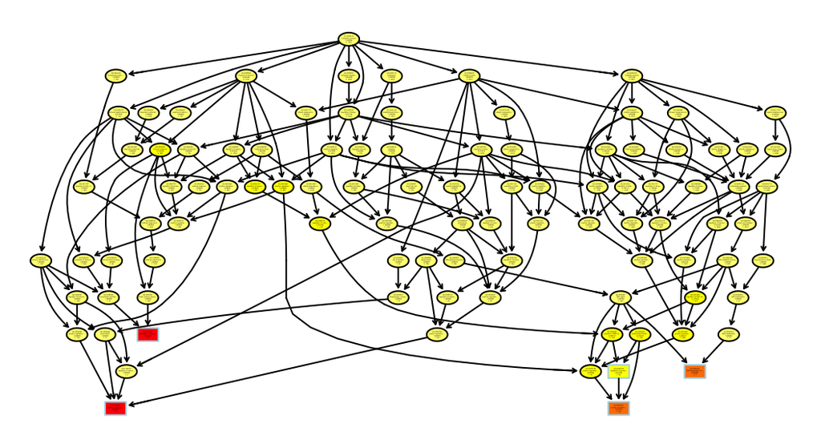

Figure 5: GO Terms for significant DEGs in pairwise comparison 1: CLL vs Control in spleen.

```
## $dag
## A graphNEL graph with directed edges
## Number of Nodes = 98
## Number of Edges = 200
##
## $complete.dag
## [1] "A graph with 98 nodes."
```

```r
# plot network graph #installed Rgraphviz package for contrast 1 (spleen):
showSigOfNodes(GOdata2,score(fisher2),
               firstSigNodes=5,useInfo='all' )
```

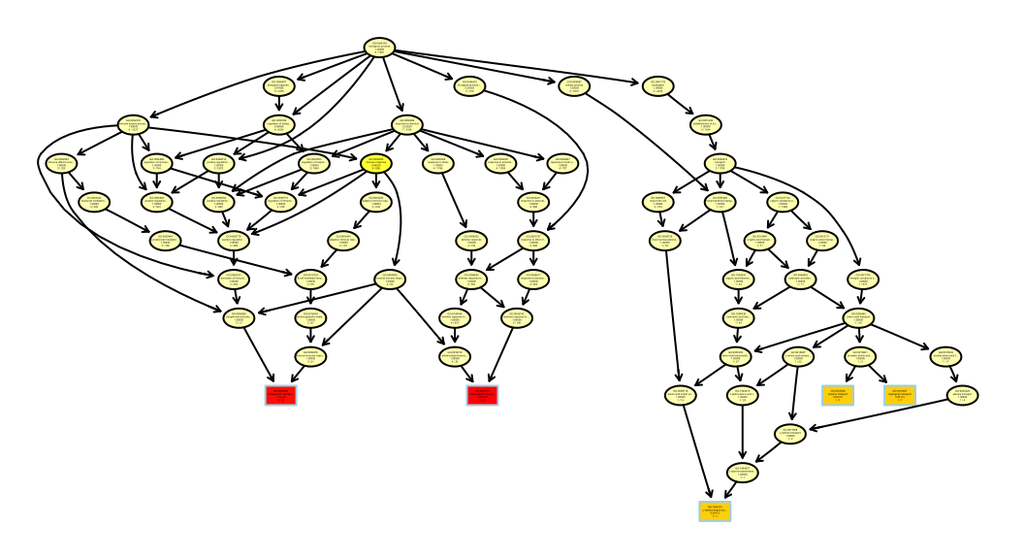

Figure 6: GO Terms for significant DEGs in pairwise comparison 2: Strong BCL vs Mild BCL in spleen.

```
## $dag
## A graphNEL graph with directed edges
## Number of Nodes = 65
## Number of Edges = 102
##
## $complete.dag
## [1] "A graph with 65 nodes."
```

```r
# plot network graph for contrast 2 (spleen):
showSigOfNodes(GOdata4,score(fisher4),
               firstSigNodes=5,useInfo='all' )
```

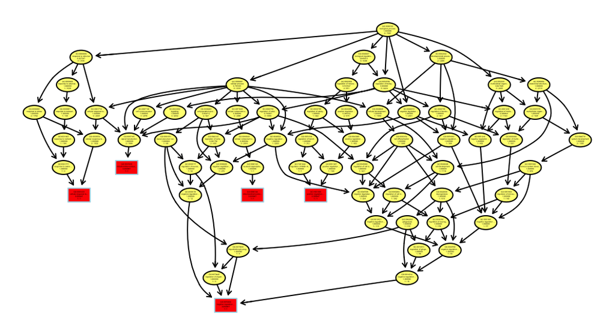

Figure 7: GO Terms for significant DEGs in pairwise comparison 3: Mild CLL vs CLL in spleen.

```
## $dag
## A graphNEL graph with directed edges
## Number of Nodes = 67
## Number of Edges = 127
##
## $complete.dag
## [1] "A graph with 67 nodes."
```

```r
# plot network graph  for contrast 3 (spleen):
showSigOfNodes(GOdata6,score(fisher6),
               firstSigNodes=5,useInfo='all' )
```

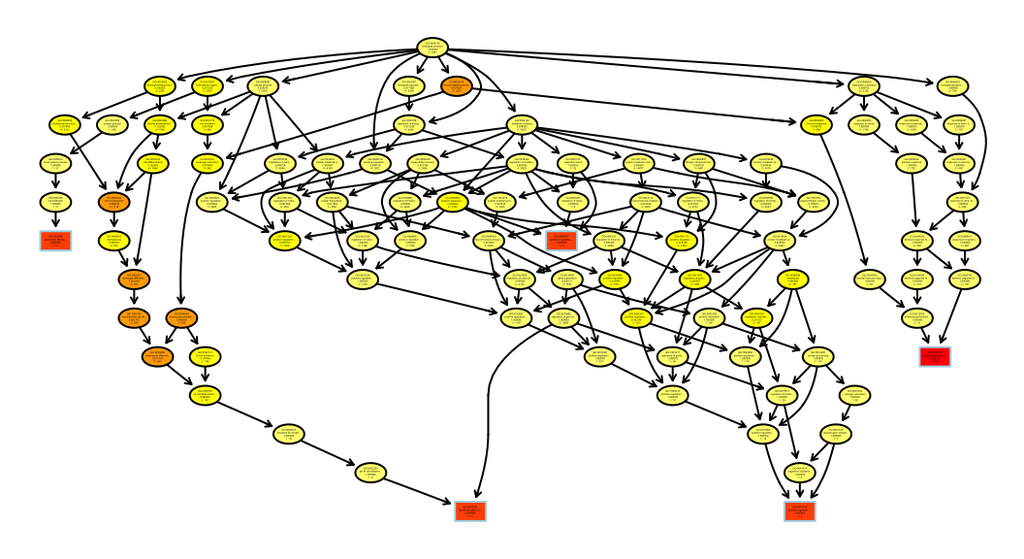

```
## $dag
## A graphNEL graph with directed edges
## Number of Nodes = 94
## Number of Edges = 180
##
## $complete.dag
## [1] "A graph with 94 nodes."
```

```r
# plot network graph for contrast 4 (spleen):
showSigOfNodes(GOdata8,score(fisher8),
               firstSigNodes=5,useInfo='all' )
```

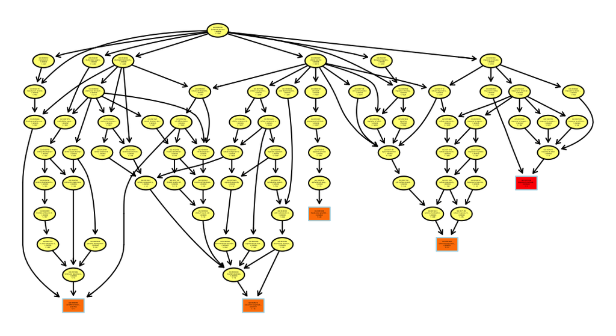

Figure 9: GO Terms for significant DEGs in pairwise comparison 3: Mild CLL vs CLL in peritoneal cavity.

```
## $dag
## A graphNEL graph with directed edges
## Number of Nodes = 75
## Number of Edges = 117
##
## $complete.dag
## [1] "A graph with 75 nodes."
```

```r
# plot network graph for contrast 3 (PC):
showSigOfNodes(GOdata5,score(fisher5),
               firstSigNodes=5,useInfo='all' )
```

## Pathway analysis

```r
# add Entrez IDs (ReactomePA works with Entrez IDs)
entrez1 <- AnnotationDbi::select(org.Mm.eg.db,keys=DEGs1[,1],
                                       keytype="SYMBOL",columns=c("SYMBOL","ENTREZID"))
path_DEGs1 <- left_join(DEGs1,entrez1,by="SYMBOL")

entrez2 <- AnnotationDbi::select(org.Mm.eg.db,keys=DEGs2[,1],
                                       keytype="SYMBOL",columns=c("SYMBOL","ENTREZID"))
path_DEGs2 <- left_join(DEGs2,entrez2,by="SYMBOL")

entrez3 <- AnnotationDbi::select(org.Mm.eg.db,keys=DEGs3[,1],
                                       keytype="SYMBOL",columns=c("SYMBOL","ENTREZID"))
path_DEGs3 <- left_join(DEGs3,entrez3,by="SYMBOL")

entrez4 <- AnnotationDbi::select(org.Mm.eg.db,keys=DEGs4[,1],
                                       keytype="SYMBOL",columns=c("SYMBOL","ENTREZID"))
path_DEGs4 <- left_join(DEGs4,entrez4,by="SYMBOL")

entrez5 <- AnnotationDbi::select(org.Mm.eg.db,keys=DEGs5[,1],
                                       keytype="SYMBOL",columns=c("SYMBOL","ENTREZID"))
path_DEGs5 <- left_join(DEGs5,entrez5,by="SYMBOL")

entrez6 <- AnnotationDbi::select(org.Mm.eg.db,keys=DEGs6[,1],
                                       keytype="SYMBOL",columns=c("SYMBOL","ENTREZID"))
path_DEGs6 <- left_join(DEGs6,entrez6,by="SYMBOL")

entrez7 <- AnnotationDbi::select(org.Mm.eg.db,keys=DEGs7[,1],
                                       keytype="SYMBOL",columns=c("SYMBOL","ENTREZID"))
path_DEGs7 <- left_join(DEGs7,entrez7,by="SYMBOL")

entrez8 <- AnnotationDbi::select(org.Mm.eg.db,keys=DEGs8[,1],
                                       keytype="SYMBOL",columns=c("SYMBOL","ENTREZID"))
path_DEGs8 <- left_join(DEGs8,entrez8,by="SYMBOL")

# retrieve logFC and gene names for cnetplot
lfc1 <- path_DEGs1$logFC
names(lfc1) <- path_DEGs1$SYMBOL

lfc2 <- path_DEGs2$logFC
names(lfc2) <- path_DEGs2$SYMBOL

lfc3 <- path_DEGs3$logFC
names(lfc3) <- path_DEGs3$SYMBOL

lfc4 <- path_DEGs4$logFC
names(lfc4) <- path_DEGs4$SYMBOL

lfc5 <- path_DEGs5$logFC
names(lfc5) <- path_DEGs5$SYMBOL

lfc6 <- path_DEGs6$logFC
names(lfc6) <- path_DEGs6$SYMBOL

lfc7 <- path_DEGs7$logFC
names(lfc7) <- path_DEGs7$SYMBOL

lfc8 <- path_DEGs8$logFC
names(lfc8) <- path_DEGs8$SYMBOL

# pathway enrichment analysis
path1 <- enrichPathway(gene=path_DEGs1$ENTREZID,pvalueCutoff=0.1,
                             organism="mouse",pAdjustMethod="BH",readable=TRUE)
path1_df <- as.data.frame(path1)

path2 <- enrichPathway(gene=path_DEGs2$ENTREZID,pvalueCutoff=0.1,
                             organism="mouse",pAdjustMethod="BH",readable=TRUE)
path2_df <- as.data.frame(path2)

path3 <- enrichPathway(gene=path_DEGs3$ENTREZID,pvalueCutoff=0.1,
                             organism="mouse",pAdjustMethod="BH",readable=TRUE)
path3_df <- as.data.frame(path3)

path4 <- enrichPathway(gene=path_DEGs4$ENTREZID,pvalueCutoff=0.1,
                             organism="mouse",pAdjustMethod="BH",readable=TRUE)
path4_df <- as.data.frame(path4)

path5 <- enrichPathway(gene=path_DEGs5$ENTREZID,pvalueCutoff=0.1,
                             organism="mouse",pAdjustMethod="BH",readable=TRUE)
path5_df <- as.data.frame(path5)

path6 <- enrichPathway(gene=path_DEGs6$ENTREZID,pvalueCutoff=0.1,
                             organism="mouse",pAdjustMethod="BH",readable=TRUE)
path6_df <- as.data.frame(path6)

path7 <- enrichPathway(gene=path_DEGs7$ENTREZID,pvalueCutoff=0.1,
                             organism="mouse",pAdjustMethod="BH",readable=TRUE)
path7_df <- as.data.frame(path7)

path8 <- enrichPathway(gene=path_DEGs8$ENTREZID,pvalueCutoff=0.1,
                             organism="mouse",pAdjustMethod="BH",readable=TRUE)
path8_df <- as.data.frame(path8)

# dotplot of ten most enriched pathways
path2_dot <- dotplot(path2,showCategory=10)+ggtitle("Comp2")
path4_dot <- dotplot(path4,showCategory=10)+ggtitle("Comp4")
path5_dot <- dotplot(path5,showCategory=10)+ggtitle("Comp5")
path6_dot <- dotplot(path6,showCategory=10)+ggtitle("Comp6")
path8_dot <- dotplot(path8,showCategory=10)+ggtitle("Comp8")

# cnetplot of the five most enriched pathways
path2_cnet <- cnetplot(path2,foldChange=lfc2,vertex.label.cex=1.2,
                             categorySize="geneNum")+ggtitle("Comp2")
path4_cnet <- cnetplot(path4,foldChange=lfc4,vertex.label.cex=1.2,
                             categorySize="geneNum")+ggtitle("Comp4")
path5_cnet <- cnetplot(path5,foldChange=lfc5,vertex.label.cex=1.2,
                             categorySize="geneNum")+ggtitle("Comp5")
path6_cnet <- cnetplot(path6,foldChange=lfc6,vertex.label.cex=1.2,
                             categorySize="geneNum")+ggtitle("Comp6")
path8_cnet <- cnetplot(path8,foldChange=lfc8,vertex.label.cex=1.2,
                             categorySize="geneNum")+ggtitle("Comp8")
```

# Comparisons using Upset plots and Venn diagrams:

## Upset plot for common significant DEGs across contrasts:

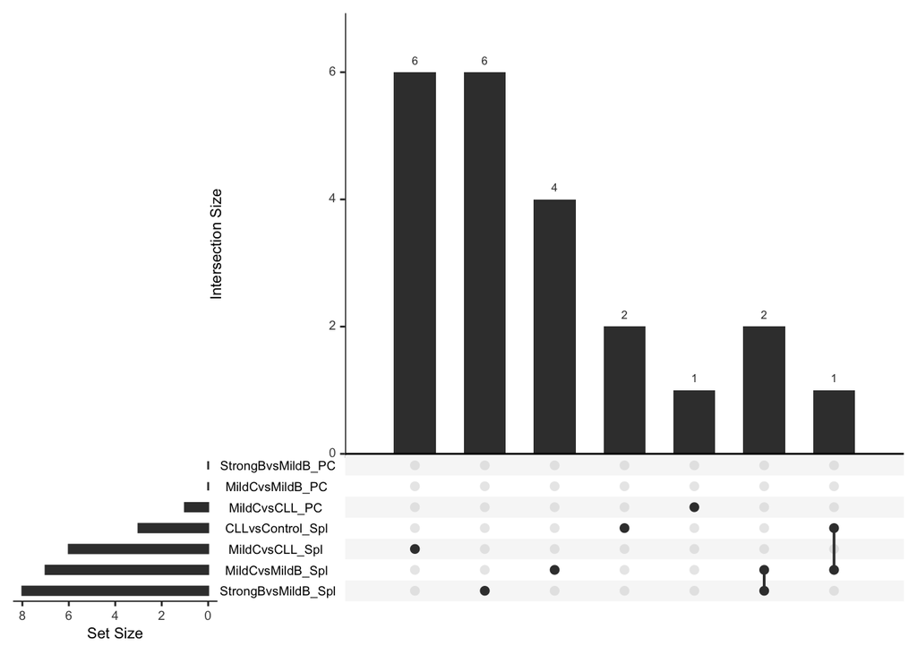

Figure 10: Upset plot of common significant Differentially Expressed genes for pre-tumor stage dataset 1.

```r
#plot common number of significant DEGs for 8 pairwise comparisons:

my.contrasts <- makeContrasts(CllPvsCP=CLL_PC-Control_PC, CllSvsCS=CLL_Spl-Control_Spl, sBPvsmBP=strong_BCL_PC-mild_BCL_PC, sBSvsmBS=strong_BCL_Spl-mild_BCL_Spl, mCPvsCllP = mild_CLL_PC-CLL_PC, mCSvsCllS = mild_CLL_Spl-CLL_Spl, mCPvsmBP = mild_CLL_PC-mild_BCL_PC, mCSvsmBS = mild_CLL_Spl-mild_BCL_Spl, levels=design_edgeR2)

list3 <- list(CLLvsControl_PC=rownames(subset(results1_df,FDR<=0.05)),
              CLLvsControl_Spl=rownames(subset(results2_df,FDR<=0.05)),
              StrongBvsMildB_PC=rownames(subset(results3_df,FDR<=0.05)),
              StrongBvsMildB_Spl=rownames(subset(results4_df,FDR<=0.05)),
              MildCvsCLL_PC=rownames(subset(results5_df,FDR<=0.05)),
              MildCvsCLL_Spl=rownames(subset(results6_df,FDR<=0.05)),
              MildCvsMildB_PC=rownames(subset(results7_df,FDR<=0.05)),
              MildCvsMildB_Spl=rownames(subset(results8_df,FDR<=0.05)))

UpSetR::upset(fromList(list3), nsets = 8)
```

## Upset plot for common significant Pathway terms among the comparisons:

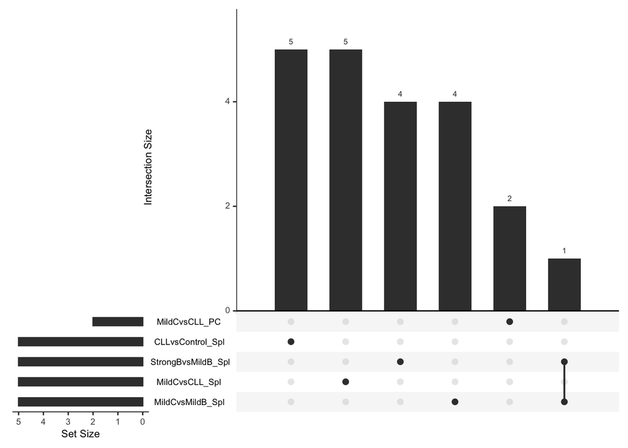

Figure 11: Upset Plot of common Significant Reactome Pathways in pre-tumor stage dataset 1.

```r
# subset significantly enriched Reactome pathways
path_up2 <- subset(path2_df,p.adjust<=0.05)
path_up4 <- subset(path4_df,p.adjust<=0.05)
path_up5 <- subset(path5_df,p.adjust<=0.05)
path_up6 <- subset(path6_df,p.adjust<=0.05)
path_up8 <- subset(path8_df,p.adjust<=0.05)

# plot Upset plot for pathway comparison:
list4 <- list(CLLvsControl_Spl=path_up2$ID,
              StrongBvsMildB_Spl=path_up4$ID,
              MildCvsCLL_PC=path_up5$ID,
              MildCvsCLL_Spl=path_up6$ID,
              MildCvsMildB_Spl=path_up8$ID)

UpSetR::upset(fromList(list4), nsets = 5)
```

## Venn Diagram of common significant GO terms across Spleen comparisons:

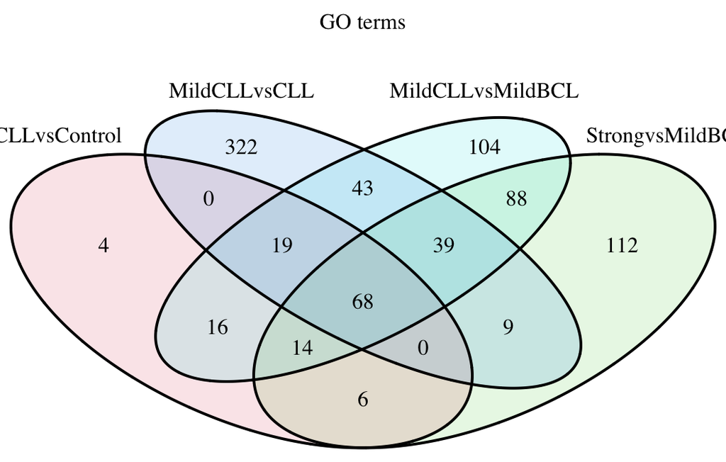

Figure 12: Venn Diagram of common Significant GO terms in spleen from pre-tumor stage dataset 1.

```r
# subset significant GO terms:
allRes1_n <- allRes1[allRes1$Significant != 0, ]
allRes2_n <- allRes2[allRes2$Significant != 0, ]
allRes3_n <- allRes3[allRes3$Significant != 0, ]
allRes4_n <- allRes4[allRes4$Significant != 0, ]
allRes5_n <- allRes5[allRes5$Significant != 0, ]
allRes6_n <- allRes6[allRes6$Significant != 0, ]
allRes7_n <- allRes7[allRes7$Significant != 0, ]
allRes8_n <- allRes8[allRes8$Significant != 0, ]

# plot Venn diagram for GO terms comparison:
venn_list2 <- list(CLLvsControl=allRes2_n$GO.ID,
                   StrongvsMildBCL=allRes4_n$GO.ID,
                   MildCLLvsCLL=allRes6_n$GO.ID,
                   MildCLLvsMildBCL=allRes8_n$GO.ID)
venn2 <- venn.diagram(venn_list2,fill=2:5,alpha=0.15,filename=NULL,
                      main="GO terms")
grid.arrange(gTree(children=venn2), ncol=1)
```

Last updated: 2024-09-29